# POL-6078

Buckinx Victor

# 1 Question de recherche et hypothèses

Il existait un blocage générationnel historique et croissant au sein de l’Assemblée nationale française. En 2007, elle affichait l’une des moyennes d’âge les plus élevées du continent, avec neuf députés seniors pour un junior. Les générations précocement élues (notamment celles issues de la Résistance en 1946 et les baby-boomers en 1981) ont maintenu leur emprise durablement, empêchant la relève et créant des « générations creuses » politiquement (Chauvel, 2007). Néanmoins, cette tendance est n’es plus d’actualité, les partis émergents (LREM en 2017, LFI et RN en 2022) ont recruté des candidats plus jeunes pour incarner le changement (Michon, 2023). De ce constat, la question suivante doit être posée : **quelle est l’évolution de l’âge des parlementaire siègeant à l’assemblée nationale depuis la 12ème législature ?**

*H1: Il n’existe pas de rajeunissement de l’Assemblée nationale.*

*H2: Il existe un rajeunissement de l’Assemblée nationale.*

# 2 Méthode

Après avoir téléchargé le fichier .csv, j’ai cherché à importer les donées sur R et à écrire un script qui permettait de répondre à la question de recherche.

# 3 Jeu de données

Le jeu de données recense tous les parlementaires siégeant à l’Assemblée nationale depuis la 12<sup>e</sup> législature. Sont présents : le numéro de leur législature, la civilité, le nom, le prénom, la ville de naissance, la date de naissance, l’âge, le groupe politique, le groupe politique dans sa forme abrégée, le nom et le code du département, la circonscription, la date de prise de fonction, la profession, les contacts (mail, Twitter, Facebook, site internet), le nombre de mandats, l’expérience député, le score de participation et le score de participation selon la spécialité, le score de loyauté envers le groupe politique, le score de majorité, l’activité, et la date de mise à jour.

Le jeu est issu d’un site gouvernemental et est régulièrement mis à jour.J’ai récupérer les données à l’adresse suivantes : https://www.data.gouv.fr/datasets/historique-des-deputes-de-lassemblee-nationale-depuis-2002-informations-et-statistiques/

# 4 Code R et graphiques

```r
library(dplyr)
```

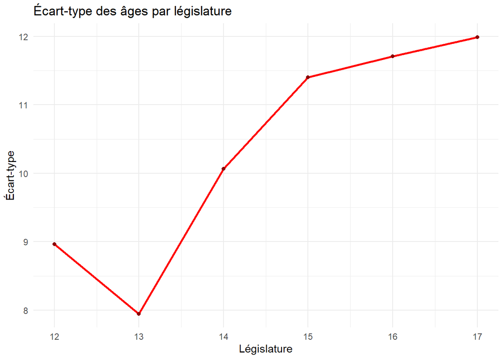

```r
library(ggplot2)
library(readr)
library(lubridate)
# 1. Importer les données
data <- read_csv("C:/Users/Victo/OneDrive/Bureau/Etude/ULaval/Session Automne/Outils numériques pour sc.so/Projet/deputes-historique.csv")
# 2. Conversion de la date (adapter si format JJ/MM/AAAA)
data <- data %>%
  mutate(dateNais = ymd(naissance))

# 3. Calculer l'âge actuel
data <- data %>%
  mutate(age = as.numeric(difftime(Sys.Date(), naissance, units = "days")) / 365.25)

# Supprimer les NA
data <- data %>% filter(!is.na(age))

# 4. Écart-type par législature
age_stats <- data %>%
  group_by(legislatureLast) %>%
  summarise(ecart_type = sd(age, na.rm = TRUE), .groups = "drop")

# 5. Regrouper par décennie
data <- data %>%
  mutate(decennie = paste0(floor(age / 10) * 10, "-", floor(age / 10) * 10 + 9))

decennie_stats <- data %>%
  group_by(legislatureLast, decennie) %>%
  summarise(count = n(), .groups = "drop")

# 6. Graphique : écart-type par législature
ggplot(age_stats, aes(x = legislatureLast, y = ecart_type)) +
  geom_line(color = "red", size = 1) +
  geom_point(color = "darkred") +
  labs(title = "Écart-type des âges par législature",
       x = "Législature", y = "Écart-type") +
  theme_minimal()
```

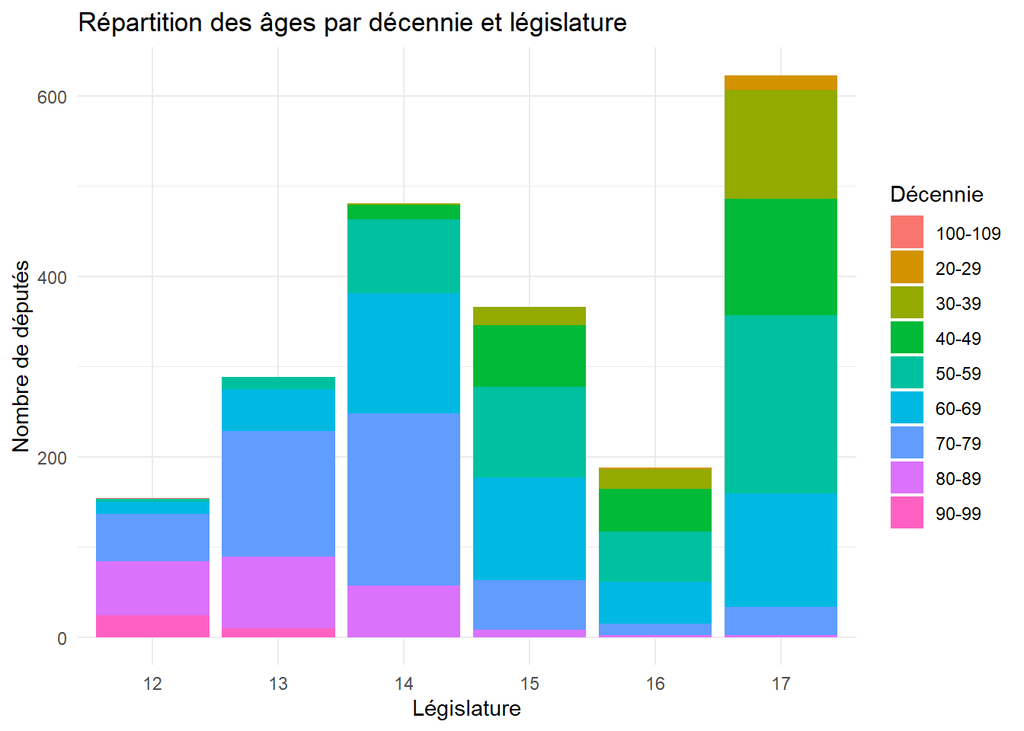

```r
# 7. Graphique : répartition par décennie
ggplot(decennie_stats, aes(x = factor(legislatureLast), y = count, fill = decennie)) +
  geom_bar(stat = "identity", position = "stack") +
  labs(title = "Répartition des âges par décennie et législature",
       x = "Législature", y = "Nombre de députés", fill = "Décennie") +
  theme_minimal()
```

# 5 Discussion

La visualisation choisie est un graphique à ligne brisée qui suit l’évolution de l’écart-type des parlementaires selon la législature. Le graphique met en évidence une évolution notable de la dispersion des âges des députés à l’Assemblée nationale entre les législatures 12 et 17. Après une légère baisse entre les législatures 12 et 13 (écart-type passant d’environ 9 à 8 ans), la tendance s’inverse à partir de la 14e législature, avec une augmentation continue jusqu’à atteindre près de 12 ans à la 17e législature.

Cette hausse traduit une diversification progressive des profils en termes d’âge : les législatures récentes accueillent à la fois des députés plus jeunes et des parlementaires expérimentés. L’accroissement observé après 2012 peut s’expliquer par des stratégies de renouvellement politique, une ouverture des partis à des générations variées et des réformes favorisant la diversité des candidatures.

# 6 Conclusion

*H1 est réfutée.*

Néanmoins ce résultat est à questionner. En effet, les données semblent incomplètes et/ou manquantes. Le graphique en barre souligne un nombre de député par législature or, le nombre de député est fixé à 577. Ainsi des données sont manquantes (législature 12 à 16) et erronées (législature 17). Les données sont incomplètes et les résultats présentés ne sont pas robuste.

# 7 Outils utilisés

Ce petit travail de fin de session m’a permit de suivre le cycle de la recherche et de passer en revue les principaux outils abordés en cours. Elicit m’a permit d’élaborer une question de recherche pertinente et un état de la littérature, Notion m’a permit de m’organiser de manière efficace et l’IA a su me sortir de certaines impasses, tant au niveau du code R que dans l’élaboration de la recherche. Plus précisément, la recherche d’article pertinent s’est faite sur Google Scholar par l’intermédiaire d’Elicit. Zotero est très utile pour regrouper, organiser les sources et citer les documents.

R est le langage le plus avantageux pour la lecture, l’analyse et la visualisation de mes données. D’autant plus que le projet en R Markdown permet d’intégrer le code R de manière lisible à la recherche. Ce projet de fin de session m’a permis de me familiariser avec les outils du numérique en recherche en sciences sociales, plus précisément à manipuler et visualiser des données à l’aide de différents packages.

Le choix de mes outils numériques de fins de sessions :

1. **l’accessibilité** : R, Zotero, IA, Elicit, Notion.
2. **l’existence d’une communauté d’utilisateurs** : Notion, Zotero, R.
3. **la popularité** : R pour la recherche en science sociale, Notion pour l’organisation des tâches, Zotero pour l’organisation des sources.
4. **leur compatibilité avec d’autres outils** : Code R intégré au R Markdown.
5. **le besoin de transparence et la réplicabilité** : Tout est disponible sur mon github, les données utilisées, le code : la réplicabilité est garantie.

# 8 Bibliographie

Michon, S. (2023). Le recrutement des députés sous la Cinquième République : entre professionnalisation et renouvellement. Revue française de science politique, 73(2), 245-268.

Chauvel L. (2007). L’âge de l’Assemblée (1946-2007), Soixante ans de renouvellement du corps législatif : bientôt, la troisième génération. La vie des idées, Collège de France.